# ggplot2 Reordering

### The Problem

In a stacked ggplot2 plot the fill ordering is not controlled by factor levels. Such plots include a stacked bar and area plot. Here is a demonstration of the problem.

```r
library(dplyr)
library(ggplot2)
```

#### Generate Data

Here I generate a data set containing a time series element (Month), counts (Count), and a leveling variable (Level). The counts are transformed to proportions and the Level variable is converted to a leveled factor with the order “High”, “Medium”, “Low”. This leveling is key to the problem as it will be used as the fill variable. It is here that reordering the factor levels will not work to reorder the plot.

```r
dat <- data_frame(
    Month = rep(sort(month.abb), each = 3),
    Count  = sample(10000:60000, 36),
    Level = rep(c("High", "Low", "Medium"), 12)
) %>%
    mutate(
        Level = factor(Level, levels = c("High", "Medium", "Low")),
        Month = factor(Month, levels = month.abb)
    ) %>%
    group_by(Month) %>%
    mutate(Prop = Count/sum(Count))
```

#### Plot a Stacked Area Plot

Next we generate the area plot. The accompanying plot demonstrates the problem. Notice that the legend is ordered according to the factor levels in the Level variable (“High”, “Medium”, “Low”) yet the plot fill ordering is not in the expected order (it is “Medium”, “Low”, “High”). I arranged the factor levels correctly but the plot fill ordering is not correct. How then can I correctly order a stacked ggplot2 plot?

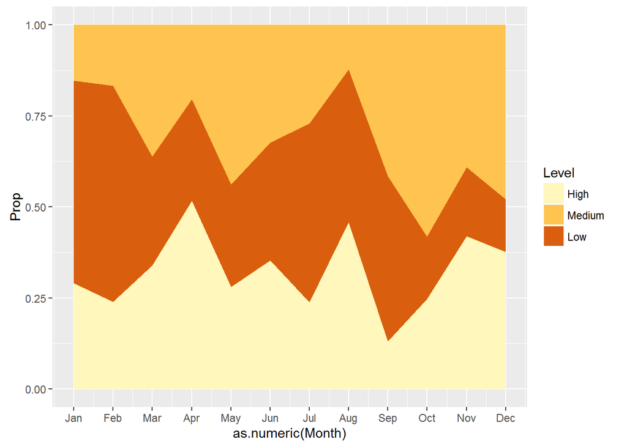

```r
dat %>%
    ggplot(aes(x=as.numeric(Month), y=Prop)) +
        geom_area(aes(fill= Level), position = 'stack') +
        scale_x_continuous(breaks = 1:12, labels = month.abb) +
        scale_fill_brewer(palette = "YlOrBr")
```

### The Solution

#### Reorder the Stacked Area Plot

It seems ggplot2 orders the plot itself by the order in which the levels are consumed. That means we need to reorder the data itself (the rows), not the factor levels, in order to reorder the plot. I use the arrange function from the dplyr package to reorder the data so that ggplot2 will encounter the data levels in the correct order and thus plot as expected. Note that base R‘s order can be used to reorder the data rows as well.

In the plot we can see that the plot fill ordering now matches the legend and factor level ordering as expected.

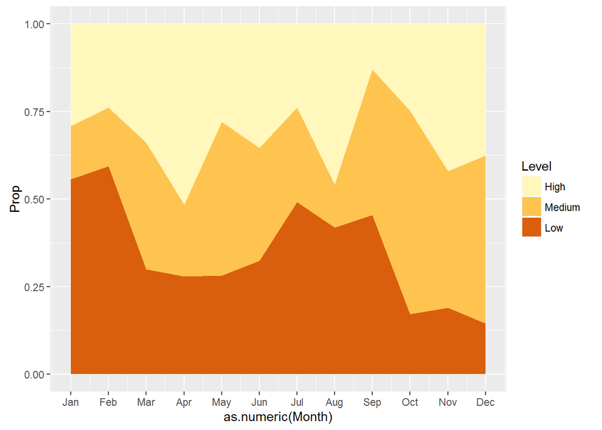

```r
dat %>%
    arrange(desc(Level)) %>%
    ggplot(aes(x=as.numeric(Month), y=Prop)) +
        geom_area(aes(fill= Level), position = 'stack') +
        scale_x_continuous(breaks = 1:12, labels = month.abb) +
        scale_fill_brewer(palette = "YlOrBr")
```

This blog post has outlined a case where reordering the factor levels does not reorder the plot and how to address the issue.